# Analiza niewypłacalności klientów

Sylvia Romek

# Wstęp

Celem jest porządkowanie klientów według największego prawdopodobieństwa niewypłacalności i pogrupowanie klientów o podobnych cechach, aby dowiedzieć się, jaki typ klienta determinuje niewywiązanie się z płatności kartą kredytową. Niewywiązanie się z płatności kartą kredytową, zwane inaczej opóźnieniem w spłacie, ma miejsce, gdy posiadacz karty nie spłaci minimalnej wymaganej kwoty lub pełnego zadłużenia do terminu określonego przez bank. W 2005 roku w Tajwanie, podobnie jak w wielu innych krajach, niewywiązanie się z płatności kartą kredytową zaczęło być poważnym problemem. Tajwan doświadczył kryzysu kredytowego związanego z nadmiernym zadłużaniem się konsumentów na kartach kredytowych i kartach debetowych. Był to okres, w którym korzystanie z kart kredytowych w kraju gwałtownie rosło, a wielu ludzi zadłużało się ponad swoje możliwości spłaty.

Przedstawione zostaną różne metody porządkowania i analizy skupień, aby zbadać różne sposoby na wysnucie wniosków, a także spróbować osiągnąć konsensus.

# Środowisko

Analizę wstępną przeprowadzono w większości przy użyciu MS Excel, a szczegółową w środowisku R, wykorzystując biblioteki:

```r
library(readxl)
library(stats)
library(ggplot2)
library(cluster)
library(clusterCrit)
library(vcd)
library(DT)
```

# Przedstawienie danych

Zestaw danych to “Default of credit card customers” z repozytorium uczenia maszynowego UCI, dostępnego pod następującym [linkiem](https://archive.ics.uci.edu/dataset/350/default+of+credit+card+clients). Zawiera 30 000 obserwacji, które reprezentują odrębnych klientów kart kredytowych. Każda obserwacja ma 24 atrybuty , które zawierają informacje o domyślnych płatnościach, czynnikach demograficznych, danych kredytowych, historii płatności i wyciągach z rachunków klientów kart kredytowych na Tajwanie od kwietnia 2005 r. do września 2005 r.

Pierwsza grupa zmiennych zawiera informacje o danych osobowych klienta :

- **ID**:ID każdego klienta, zmienna kategoryczna
- **LIMIT_BAL**:Kwota przyznanego kredytu w dolarach NT
- **SEX**:Płeć, zmienna kategorialna (1=mężczyzna, 2=kobieta) (ta zmienna w tym projekcie nie została uwzględniona)
- **EDUCATION**:poziom wykształcenia, zmienna kategorialna (1=szkoła podyplomowa, 2=uniwersytet, 3=szkoła średnia, 4=inne, 5=nieznane, 6=nieznane)
- **MARRIAGE**:Stan cywilny, zmienna kategorialna (1=żonaty, 2=singiel, 3=inne)
- **AGE**:Wiek w latach, zmienna liczbowa

Poniższe atrybuty zawierają informacje o opóźnieniu płatności w danym miesiącu:

- **PAY_0**:Status spłaty we wrześniu 2005 r. (-1=należy zapłacić, 1=opóźnienie w spłacie o jeden miesiąc, 2=opóźnienie w spłacie o dwa miesiące, … 8=opóźnienie w spłacie o osiem miesięcy, 9=opóźnienie w spłacie o dziewięć miesięcy i więcej)
- PAY_2:Status spłaty w sierpniu 2005 r. (taka sama skala jak poprzednio)
- PAY_3:Status spłaty w lipcu 2005 r. (ta sama skala co poprzednio)
- PAY_4:Status spłaty w czerwcu 2005 r. (ta sama skala co poprzednio)
- PAY_5:Status spłaty w maju 2005 r. (taka sama skala jak poprzednio)
- PAY_6:Status spłaty w kwietniu 2005 r. (taka sama skala jak poprzednio)

**Z powyższych zmiennych do projektu została uwzględniona tylko PAY_0, ze względu na najwyższą korelację z default_payment_next_month**

Inne zmienne biorą natomiast pod uwagę informacje związane z kwotą rachunku (czyli miesięcznym raportem, który firmy obsługujące karty kredytowe wydają posiadaczom kart kredytowych w danym miesiącu):

- BILL_AMT1:Kwota rachunku we wrześniu 2005 r. (dolar NT)
- BILL_AMT2:Kwota rachunku w sierpniu 2005 r. (dolar NT)
- BILL_AMT3:Kwota rachunku w lipcu 2005 r. (dolar NT)
- BILL_AMT4:Kwota rachunku w czerwcu 2005 r. (dolar NT)
- BILL_AMT5:Kwota rachunku w maju 2005 r. (dolar NT)
- BILL_AMT6:Kwota rachunku w kwietniu 2005 r. (dolar NT)

**Powyższe zmienne zostały uwzględnione do projektu jako nowa zmienna - średnia z kwot rachunków od 04.2005 do 09.2005 pod nazwą BILL_MEAN**

Poniższe zmienne uwzględniają natomiast kwotę poprzedniej płatności w danym miesiącu:

- PAY_AMT1:Kwota poprzedniej płatności we wrześniu 2005 r. (dolar NT)
- PAY_AMT2:Kwota poprzedniej płatności w sierpniu 2005 r. (dolar NT)
- PAY_AMT3:Kwota poprzedniej płatności w lipcu 2005 r. (dolar NT)
- PAY_AMT4:Kwota poprzedniej płatności w czerwcu 2005 r. (dolar NT)
- PAY_AMT5:Kwota poprzedniej płatności w maju 2005 r. (dolar NT)
- PAY_AMT6:Kwota poprzedniej płatności w kwietniu 2005 r. (dolar NT)

**Powyższe zmienne zostały uwzględnione do projektu jako nowa zmienna - średnia z kwot z poprzedniej płatności od 04.2005 do 09.2005 pod nazwą PAY_MEAN**

Ostatnia zmienna to:

- default.payment.next.month: wskaż, czy posiadacze kart kredytowych są osobami uchylającymi się od spłat czy nie (1=tak, 0=nie)

*Nie jest brana w obliczeniach, pełni funkcję odniesienia i weryfikacji do otrzymanych wyników.*

**Dodatkowo wybrane obserwacje zostały dodatkowo wyselekcjonowane, biorąc pod uwagę tylko te cechy, które są uwzględnione w dokumentacji. Oto następujące filtracje wierszy:**

- w kolumnie MARRIAGE usunięcie wartości 0
- w kolumnach PAY_1, PAY_2 itd usunięcie wartości -2 i 0
- w kolumnie EDUCATION usunięcie wartości 0, 5, 6

**Po tych zabiegach zostało 4031 wierszy, a w niniejszym projekcie uwzględniono 50 pierwszych obserwacji.**

Podgląd 5 pierwszych obserwacji:

| ID | LIMIT_BAL | EDUCATION | MARRIAGE | AGE | PAY_0 | BILL_MEAN | PAY_MEAN | default payment next month |
| --- | --- | --- | --- | --- | --- | --- | --- | --- |
| 12 | 260,000 | 1 | 2 | 51 | -1 | 14,728.167 | 11,051.3333 | 0 |
| 22 | 120,000 | 2 | 1 | 39 | -1 | 316.000 | 263.3333 | 1 |
| 29 | 50,000 | 3 | 1 | 47 | -1 | 6,701.333 | 6,594.5000 | 0 |
| 31 | 230,000 | 1 | 2 | 27 | -1 | 18,957.667 | 16,248.1667 | 0 |
| 49 | 380,000 | 2 | 2 | 32 | -1 | 19,135.833 | 15,555.3333 | 0 |

# Wstępna analiza

## Podstawowe informacje o zbiorze danych:

[figure not shown]

Zwróćmy uwagę, że średni przyznany kredyt wynosi 184 400 $ NT, średni wiek to 37 lat, średni rachunek w badanym okresie to 23 846 $ NT przy czym średnia spłata to 6196,54 $ NT, co oznacza, że **poziom wypłacalności przez klientów jest bardzo niski**. Analizując medianę w tym samym okresie, wynosi ona dla

- rachunku: 6838 $ NT,
- płatności: 2358 $ NT

i **potwierdza** ona, że jest duży problem ze spłatami zobowiązań. WSpółczynnik zmienności dla wszytskich zmiennych spełnia warunek >10%, aby brać te zmienne pod uwagę w dalszej analizie.

Głównym celem jest opis struktury klientów i klasyfikacja wedlug klientów z największym prawdopodobieństwem utraty płynności spłacania zobowiązania, dlatego spojrzmy na przewidywana płatność w następnym miesiącu (zmienna “default_payment_next_month”), która kształtuje się następująco:

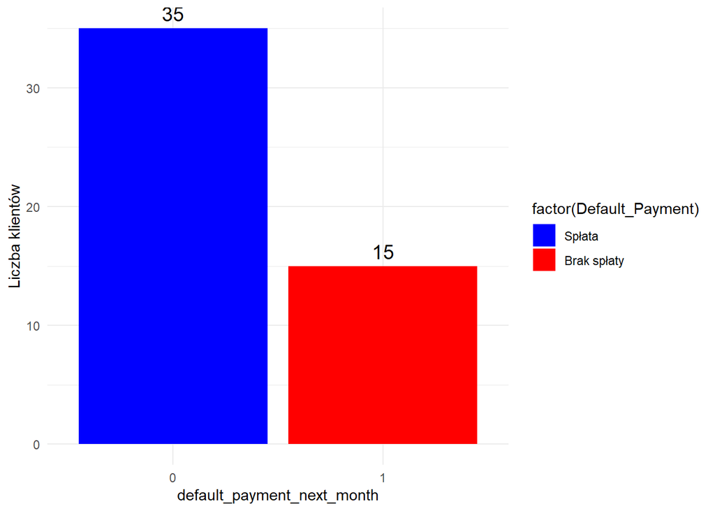

Jak widać, 15 z 50 (30%) klientów nie wykona spłaty w następnym miesiącu(kat. 1).

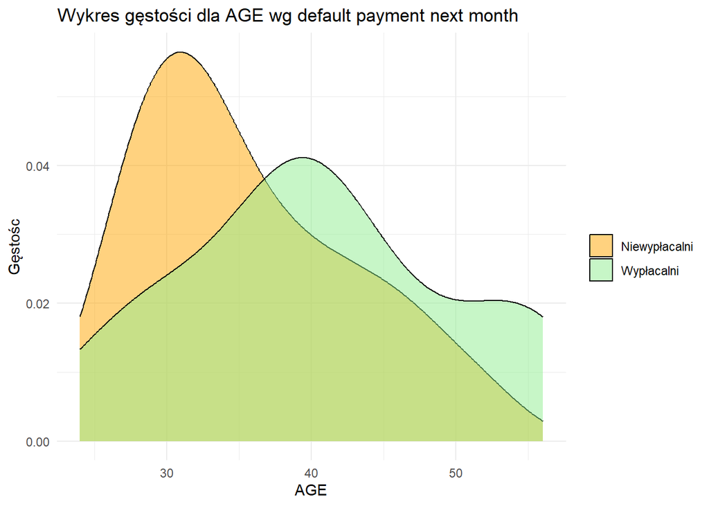

Zdecydowanie można swierdzić, że im młodszy klient, tym większe prawdopodobieństwo niewypłacalności - jest ponad dwukrotnie wyższe dla wieku 30 niż w wieku 50 lat.

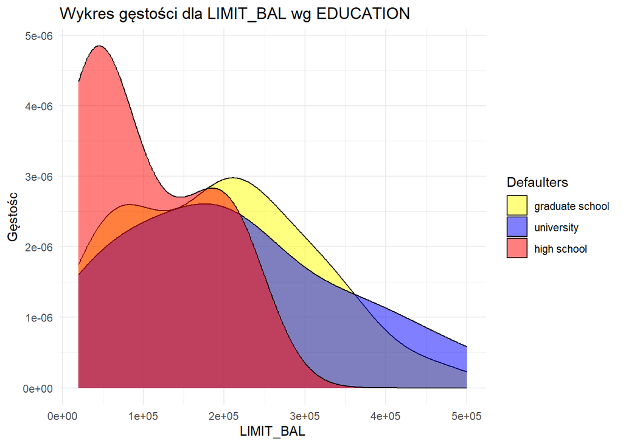

Podany wykres przedstawia, że osoby z wykształceniem średnim mają przyznany niski kredyt i takich osób jest najwięcej w zbiorze. Największe przyznane kredyty są u osób po uzyskaniu tytułu studiów 1 stopnia.

## Korelacja

[figure not shown]

## Wykres pudełkowy

[figure not shown]

Zatem obserwacje odstające zostają usunięte zgodnie z regułą trzech sigm:

```r
set.seed(123)
dane_podst <- read_excel("edited_default_clients.xlsx")
# Funkcja usuwająca obserwacje odstające na podstawie reguły 3 sigm
 usun_odstajace <- function(df) {
  # Dla każdej kolumny liczenie średniej i odchylenia standardowego
  for (col in colnames(df)) {
    mean_col <- mean(df[[col]], na.rm = TRUE)  # średnia dla kolumny
    sd_col <- sd(df[[col]], na.rm = TRUE)      # odchylenie standardowe dla kolumny

    # Filtrowanie dane, usuwając wartości poza zakresem (średnia ± 3 * odchylenie standardowe)
    df <- df[abs(df[[col]] - mean_col) <= 3 * sd_col, ]
  }
  return(df)
}

# Usunięcie wierszy z wartościami odstającymi
dane_bez_odstajacych <- usun_odstajace(dane_podst)

# Porównanie liczby wierszy przed i po usunięciu odstających obserwacji
nrow(dane_podst)           # Liczba wierszy przed usunięciem odstających obserwacji
```

```
## [1] 50
```

```r
nrow(dane_bez_odstajacych)  # Liczba wierszy po usunięciu odstających obserwacji
```

```
## [1] 48
```

Po usunieciu zostało 48 obserwacji.

# Porządkowanie liniowe

## Wstęp:

Przeprowadzona analiza miała na celu uporządkowanie danych w sposób liniowy (stworzenie rankingu) osób potecjalnie zagrożonych niewypłacalnością przy użyciu różnych metod porządkowania, aby zidentyfikować. Zastosowano 4 metody: metodę standaryzowanych sum, metodę sumy rang, metodę Hellwiga i TOPSIS.

Dane zostały porządkowane według klientów (zmienna “ID”) z malejącym prawdopodobieństwem niewypłacalności

## Przygotowanie danych (zgodnie z schematem):

1. **Przyjmuję, że stymulanty to:**
- PAY_0
- LIMIT_BAL
- BILL_MEAN

Destymulanty:

- EDUCATION
- AGE
- MARRIAGE
- PAY_MEAN

Brak nominant.

```r
dane<-dane_bez_odstajacych
# Zamiana destymulanty na stymulantę
dane$EDUCATION <- -1 * dane$EDUCATION
dane$AGE <- -1 * dane$AGE
dane$MARRIAGE <- -1 * dane$MARRIAGE
dane$PAY_MEAN <- -1 * dane$PAY_MEAN
```

2. **Dokonywanie standaryzacji:**

```
##        ID           LIMIT_BAL          EDUCATION          MARRIAGE
##  Min.   : 12.00   Min.   :-1.30702   Min.   :-1.9964   Min.   :-0.9491
##  1st Qu.: 77.25   1st Qu.:-0.86350   1st Qu.:-0.5872   1st Qu.:-0.9491
##  Median :174.00   Median : 0.06384   Median : 0.8220   Median :-0.9491
##  Mean   :175.71   Mean   : 0.00000   Mean   : 0.0000   Mean   : 0.0000
##  3rd Qu.:268.00   3rd Qu.: 0.50735   3rd Qu.: 0.8220   3rd Qu.: 1.0317
##  Max.   :343.00   Max.   : 2.56363   Max.   : 0.8220   Max.   : 1.0317
##       AGE              PAY_0           BILL_MEAN           PAY_MEAN
##  Min.   :-2.2963   Min.   :-0.7116   Min.   :-0.58835   Min.   :-4.1292
##  1st Qu.:-0.5195   1st Qu.:-0.7116   1st Qu.:-0.55653   1st Qu.:-0.2227
##  Median : 0.1129   Median :-0.7116   Median :-0.40654   Median : 0.4272
##  Mean   : 0.0000   Mean   : 0.0000   Mean   : 0.00000   Mean   : 0.0000
##  3rd Qu.: 0.8357   3rd Qu.: 0.9236   3rd Qu.:-0.00681   3rd Qu.: 0.6196
##  Max.   : 1.5585   Max.   : 2.1955   Max.   : 3.28715   Max.   : 0.7383
##  default payment next month
##  Min.   :0.0000
##  1st Qu.:0.0000
##  Median :0.0000
##  Mean   :0.2708
##  3rd Qu.:1.0000
##  Max.   :1.0000
```

# Metody porządkowania

## 1. Metoda standaryzowanych sum (bezwzorcowa)

*Opis:* Po odpowiednim przygotowaniu danych (krok wyżej), zostaje obliczona średnia ważona dla poszczególnego klienta, następnie standaryzowane są wartości w oparciu o najmniejszą i największą wartość. Ostatecznie klienci są posortowani od “najgorszego” do “najlepszego” w kontekście wypłacalności.

*Zaiplementowanie:*

### **Próba 1 - Nadanie wag wg regresji (y-“default payment next month”):**

[figure not shown]

**Analizując regresję, tylko zmienna PAY_0 ma istotnie statyczny wpływ na y - “default payment next month”, dlatego wagi zostały nadane według korelacji, a następnie zgodnie z nią znormalizowane na podstawie zmiennej “default payment next month”. W ten sposób suma wag wynosi 1.**

### **Próba 2 - Nadanie wag wg korelacji z “default payment next month”:**

```r
# Obliczanie korelacji zmiennych (z zmienna "default")
korelacje <- cor(dane_st[, c("LIMIT_BAL", "EDUCATION", "MARRIAGE", "AGE", "PAY_0", "BILL_MEAN", "PAY_MEAN")], dane_st$"default payment next month")

# Przekształcanie korelacji na wagi (np. przez normalizację wartości absolutnych)
wagi <- abs(korelacje) / sum(abs(korelacje))
wagi
```

```
##                 [,1]
## LIMIT_BAL 0.02319689
## EDUCATION 0.18754474
## MARRIAGE  0.13484611
## AGE       0.13559148
## PAY_0     0.25482761
## BILL_MEAN 0.17373014
## PAY_MEAN  0.09026303
```

```
##     ID stand_suma
## 17 113 1.00000000
## 14  91 0.96919878
## 46 330 0.88446302
## 37 277 0.87345418
## 10  72 0.81583127
## 19 119 0.67677916
## 8   68 0.64168523
## 13  78 0.61500832
## 23 162 0.61354179
## 42 307 0.58143837
## 35 263 0.56764177
## 28 196 0.56760372
## 22 159 0.56492444
## 25 176 0.56198611
```

[output cut: 34 more lines]

#### Wyniki i wnioski próba 2:

Przyjrzenie się top 10:

[figure not shown]

Na czerwono są wiersze, które faktycznie powinny byc sklasyfikowane jak najwyżej, ale jest to 50% z rankingowanych top 10, w zbiorze danych znajdują sie klienci, którzy zdecydowanie powinni być na wyższym miejscu. Reszta klientów została sklasyfikowana ze względu na miskie wartości pay_mean i bill_mean w stosunku do wysokiego limit_bal.

Zmienna weryfikująca (default payment next year) ma sumę 3, co oznacza że 3 osoby wśrod przedstawionych wyżej będą niewypłacalne w przyszłym miesiącu, zatem odrzucam ten sposób.

### **Próba 3 - Nadanie wag na podstawie analizy głównych składowych (PCA)**

WAGI:

```
##  LIMIT_BAL  EDUCATION   MARRIAGE        AGE      PAY_0  BILL_MEAN   PAY_MEAN
## 0.02750909 0.19058094 0.20869645 0.20315391 0.16184716 0.17790033 0.03031212
```

Uporządkowanie:

```
##     ID stand_suma
## 14  91 1.00000000
## 17 113 0.97024995
## 46 330 0.94606848
## 22 159 0.93301172
## 10  72 0.87121597
## 37 277 0.83385818
## 28 196 0.80893662
## 7   63 0.79117209
## 19 119 0.67474735
## 8   68 0.66262351
## 24 172 0.63533572
## 23 162 0.63226904
## 13  78 0.60265757
## 33 244 0.58722441
```

[output cut: 34 more lines]

#### Wyniki i wnioski próba 3:

Przyjrzenie się top 10:

[figure not shown]

Analizując 10 pierwszych najgorszych klientów, wyniki na pierwszy rzut oka są trafne. Oprócz klientów z drastycznymi różnicami między rachunkiem a zapłatą i spóznieniem z płatnością, znalazła się dwójka klientów zalegających z zapłatą. Początkowo wygladają niegroźnie, gdyż są podobne wartości w BILL_MEAN i PAY_MEAN, lecz ich kwota kredytu jest bardzo wysoka w stosunkiu do spłat. Uwzględniając ich 2-miesięczne opóznienie ze spłatą, jak najbardziej powinni się znaleźć wysoko w rankingu.

- Przewidywana liczba osób, którzy osiągną niewypłacalność w następnym miesiącu wśród tych klientów wynosi 6 (na podstawie zmiennej default_next_payment).
- 60% z nich ma najniższe wykształcenie.
- Większość osób ma ponad 30 lat.
- Średnia przyznanego kredytu wynosi 233 000$

[figure not shown]

Przyglądając się dalszym danym - kolejne 10 klientów (bez zachowania kolejności), także wydają się rozsądnie przyporządkowane.

- Widać tendencje, że płacą na czas (80% osób)
- 60% znich ma najniższe wykształcenie
- Średnia przyznanego kredytu wynosi 177 000$

[figure not shown]

Powyżej jest 10 klientów “najlepszych”, czyli potencjalnie najmniej ryzykownych pod względem niewypłacalności.

- Widać, że wysokośc kredytów jest niższa, ostatnia płatnośc w większości na czas, podobne średnie rachunki i płatności.
- 80% z nich nie jest singlami.
- Średnia przyznanych kredytów wynosi 150 000$

## Próba 4 - bez wag

Wyniki:

```
##     ID stand_suma
## 17 113  1.0000000
## 46 330  0.9803828
## 37 277  0.9563378
## 14  91  0.9532916
## 10  72  0.8192060
## 8   68  0.7094922
## 28 196  0.6811734
## 7   63  0.6662728
## 22 159  0.6652651
## 42 307  0.6584802
## 13  78  0.5943681
## 19 119  0.5599093
## 24 172  0.5560156
## 40 293  0.5541787
```

[output cut: 34 more lines]

[figure not shown]

Powyżej 10 najgorszych klientów

**Jak widać, brak zastosowania wag daje bardzo zbliżone wyniki do wag nadanych poprzez PCA.** Metoda z PCA wydaje się być mniej wrażliwa na LIMIT_BAL, a bardziej wrażliwa na BILL_MEAN niż obliczanie bez nadanych wag.

*Przewidywana liczba osób, którzy osiągną niewypłacalność w następnym miesiącu wśród tych klientów wynosi 6 (na podstawie zmiennej default_next_payment).

### **Podsumowanie**

W wybranym zbiorze danych przy metodzie standaryzowanych sum nadanie wag zmiennym okazało się zbędne, być może ze względu na przewagę zmiennych kategorycznych o wąskich zakresach. Metoda ta, dobrze sprawdziła się w porządkowaniu danych z tyloma zmiennymi.

Widać, kluczowych pięciu klientów (ID: 113, 330, 277, 91 i 72) z najwyższym ryzykiem niewypłacenia (>0,8) w stosunku do obecnych danych. Reszta klientów również jest przyporządkowana akceptowalnie. Minus tej metody jest taki, że nie uwzględniamy korelacji między zmiennymi, przez co końcowy wynik może wychodzić zakłamany. Także cięzko jest dobrać odpowiednio wagi, trzeba szukać metody i jest to subiektywne.

Jest tendencja, że u klientów, którzy zaciagąją wyższy kredyt, są singlami i mają niski stopień edukacji wzrasta potencjał niewypłacalności.

Klienci z najniższym potencjałem wypłacalności płacą na czas i nie są singlami.

## 2. Metoda sumy rang (bezwzorcowa)

*Opis:* Po odpowiednim przygotowaniu danych, zostają obliczone rangi dla każdej zmiennej z osobna a następnie rangi zostają sumowane. Najniższej wartości (najgorszej dla stymulant) przypisuje się wartośc 1 itd aż do najwyższej wartości, która otrzyma najwyższą rangę. Klient z najwyższą sumą rang, interpretowany jest jako, ten, który posiada najwiękze predyspozycje do niewypłacalności. Wyniki są przedstawione od “najgorszego” klienta do “najlepszego”. Nie zastosowano wag, aby wyniki były porównywalne z innymi metodami

```
## Wyniki metody suma rang:
```

```
##     ID suma_rang
## 37 277     261.5
## 10  72     259.0
## 28 196     253.0
## 7   63     252.5
## 14  91     250.5
## 46 330     235.5
## 17 113     222.5
## 8   68     218.5
## 22 159     218.5
## 26 187     215.5
## 47 331     211.5
## 45 327     206.5
## 18 117     205.0
## 25 176     204.5
```

[output cut: 34 more lines]

```
## # A tibble: 48 × 3
##    ID    stand_suma ranga_suma
##    <chr>      <dbl>      <dbl>
##  1 113        1           222.
##  2 330        0.980       236.
##  3 277        0.956       262.
##  4 91         0.953       250.
##  5 72         0.819       259
##  6 68         0.709       218.
##  7 196        0.681       253
##  8 63         0.666       252.
##  9 159        0.665       218.
## 10 307        0.658       199
## # ℹ 38 more rows
```

Porównując do metody poprzedniej pierwszych “najgorszych” 9 klientów jest takich samych, różnią się, ale jednak są w czołówce. Analizując kolejną dziesiątke w zestawieniu, to tylko dwóch klientów pokrywa się (są obecni od 10 do 20 miejsca w metodzie standaryzowanych sum)

[figure not shown]

Analizując dane od najmniejszej sumy rang, czyli od najlepszych klientów, faktycznie wszyscy ostatnią płatnośc zapłacili na czas, zmienna default_payment_next_month wynosi 0, czyli przewiduje, że wszyscy w następnym miesiącu zapłacą. 90% z nich ma więcej niż 34 lata. Średnia kredytu wynosi 124 000$. Tą metodą uporządkowanie jest lepiej dostosowane dla 10 najlepszych klientów od poprzedniej metody.

W tej metodzie rozkład klientów z pewnymi cechami pokrywa się z poprzednią metodą tj tendencja, że klienci z najmniejszym potencjałem ryzyka niewypłacalności mają niższe kredyty i spłacają zobowiązania na czas.

*Minus tej metody to taki, że ciężko ocenić na pierwszy rzut oka, co znaczy ta suma rang dla poszczególnego klienta bez kontekstu innych, jaki wynik jest najwyższy, a jaki najniższy. Brakuje konktekstu do czego porównywać, jaki jest zakres. W tym przypadku ze względu na 7 zmiennych i 48 obiektów, to najwyższa waga wynosi 336, najniższa 7. Nie pokazuje tak dobrze odległości między “miejscami” w rankingu.

## 3. Metoda Hellwiga (wzorcowa)

*Opis:* Po odpowiednim przygotowaniu danych, wyznaczony zostaje wzorzec na podstawie najlepszej wartości z każdej zmiennej. Jest to nowy obiekt zawierający najlepszy zestaw cech z podanych zmiennych.

W kontekście tego projektu - porządkowaniu według najbardziej zagrożonych niewypłacalnością klientów, wzorzec to fikcyjny “najgorszy” klient zawierający najwyższe wartości spośród podanego zbioru danych, z najwyższą predyspozycją do niewypłacalności.

Nastepnie jest liczona odległość każdego klienta do wzorca, w kolejnym kroku tworzy się fikcyjnego klienta “możliwie dalekiego” od wzorca. Miara dla każdego klienta zostaje obliczona poprzez podzielenie “jego odległości od wzorca” przez fikcyjnego klienta “możliwie dalekiego” od wzorca. Aby wyniki były od wartości najwyższej oznaczającej największą bliskość do wzorca, to zostało obliczone poprzez 1- miara. Wyniki są przedstawione od “najgorszego” klienta do “najlepszego”

*Wzorzec:*

```
## [1] 2.1954903 2.5636318 3.2871532 1.5584985 1.0316548 0.8220480 0.7383482
```

```
##     ID    Hellwig
## 17 113 0.55602306
## 46 330 0.49972127
## 10  72 0.49362977
## 37 277 0.41353603
## 14  91 0.40838344
## 22 159 0.35379180
## 8   68 0.32194222
## 42 307 0.30177615
## 19 119 0.29663859
## 28 196 0.29394657
## 47 331 0.29357023
## 7   63 0.28513855
## 24 172 0.25807030
## 11  73 0.24156218
```

[output cut: 34 more lines]

Takie oto wartości przyjmuje 10 klientów potencjalnie bardziej ryzykownych pod względem niewypłacalności:

[figure not shown]

Im bliższy jest wynik do 1, tym bardziej obserwacja przypomina wzorzec, a zatem klient ma większe ryzyko niewypłacalności. Wynik bliższy 0 oznacza, że obserwacja jest bardziej odległa od wzorca, co wskazuje na niższe ryzyko niewypłacalności.

**Wnioski z przedstawionej tabeli:**

- Patrząc na przykład klienta z ID 113, który ma wynik 0.556, można powiedzieć, że jest on relatywnie bliski “ryzykownemu” wzorcowi. Klient z ID 63, z wynikiem 0.285, jest bardziej oddalony od tego wzorca, co czyni go prawdopodobnie mniej ryzykownym w ocenie kredytowej.
- 50% najgorszych kredytobiorców to osoby mające 40 lat i więcej i taki sam odsetek ma niskie wykształcenie.
- Przewidywana liczba osób, którzy osiągną niewypłacalność w następnym miesiącu wśród tych klientów wynosi 5 (na podstawie zmiennej default_next_payment).
- 70% klientów potencjalnie bardziej ryzykownych pod względem niewypłacalności to single i tyle samo zalega 2 miesiące z ostatnią płatnością
- Średnia przyznanego kredytu to 278 000$

## 4. Metoda TOPSIS (wzorcowa)

*Opis:* Po odpowiednim przygotowaniu danych, wyznaczony zostaje wzorzec i antywzorzec.

W kontekście tego projektu - porządkowaniu według najbardziej zagrożonych niewypłacalnością klientów, wzorzec to taki sam obiekt jak w metodzie Hellwiga, antywzorzec analogicznie fikcyjny “najlepszy” klient zawierający najniższe wartości spośród podanego zbioru danych, z najniższą predyspozycją do niewypłacalności.

Nastepnie jest liczona odległość każdego klienta do wzorca i antywzorca, w kolejnym kroku tworzy się współczynnik rankingowy określający podobieństwo obiektów do rozwiązania idealnego**.** Wyniki są przedstawione od “najgorszego” klienta do “najlepszego”.

*Wyniki:*

```
## # A tibble: 48 × 2
##    ID    TOPSIS
##    <chr>  <dbl>
##  1 330    0.663
##  2 277    0.649
##  3 72     0.634
##  4 113    0.621
##  5 68     0.571
##  6 196    0.570
##  7 91     0.565
##  8 307    0.562
##  9 159    0.561
## 10 63     0.557
## 11 119    0.539
## 12 78     0.538
```

[output cut: 36 more lines]

  Charakterystyka 10 klientów najbardziej zbliżonych do wzorca:

[figure not shown]

- Średnia przyznanego kredytu wynosi 256 000$
- 50% z nich ma niskie wykształcenie i 70% ma niskie wykształcenie
- Tylko 30% osób ostatnią płatność opłaciło w terminie
- Przewidywana liczba osób, którzy osiągną niewypłacalność w następnym miesiącu wśród tych klientów wynosi 5 (na podstawie zmiennej default_next_payment).

# **Podsumowanie i porównanie metod porządkowania**

```
##     ID Hellwig stand_suma suma_rang TOPSIS
## 3  113    0.56       1.00     222.5   0.62
## 36 330    0.50       0.98     235.5   0.66
## 44  72    0.49       0.82     259.0   0.63
## 25 277    0.41       0.96     261.5   0.65
## 48  91    0.41       0.95     250.5   0.57
## 9  159    0.35       0.67     218.5   0.56
## 42  68    0.32       0.71     218.5   0.57
## 31 307    0.30       0.66     199.0   0.56
## 5  119    0.30       0.56     197.0   0.54
## 15 196    0.29       0.68     253.0   0.57
## 37 331    0.29       0.51     211.5   0.51
## 41  63    0.29       0.67     252.5   0.56
## 11 172    0.26       0.56     201.5   0.52
## 45  73    0.24       0.50     185.5   0.51
```

[output cut: 34 more lines]

```
##            Hellwig stand_suma suma_rang TOPSIS
## Hellwig       1.00       0.94      0.79   0.91
## stand_suma    0.94       1.00      0.84   0.94
## suma_rang     0.79       0.84      1.00   0.84
## TOPSIS        0.91       0.94      0.84   1.00
```

W tabelce niżej wszyscy klienci, którzy pojawili się w danej metodzie w top 10

[figure not shown]

Wyniki tych metod są spójne, ogólne dane 1 grupy klientów - zagrożonych niewypłacalnością:

- Średnie zadłuzenie to 244 286$
- 57% osób ma niskie wykształcenie , 64% jest singlami, średnia ich wieku to 40 lat, 71% ma opóźnienie w płatności,
- Średnia wartość rachunku to 51 740$ , zapłaty 5 585$, czyli w 10% spłacają swój rachunek

Druga grupa klientów ze średnim ryzykiem ma następujące cechy:

- Średnie zadłuzenie to 172 857$
- 46% osób ma niskie wykształcenie , 39% jest singlami, średnia ich wieku to 35 lat, 25% ma opóźnienie w płatności,
- Średnia wartość rachunku to 14 706$ , zapłaty 6 224$, czyli w 42% spłacają swój rachunek

Trzecia grupa klientów z niskim ryzykiem ma następujące cechy:

[figure not shown]

- Średnie zadłuzenie to 120 000$
- 75% osób ma niskie wykształcenie , 38% jest singlami, średnia ich wieku to 40 lat, 12% ma opóźnienie w płatności,
- Średnia wartość rachunku to 7 022$ , zapłaty 7 169$, czyli spłacają swój rachunek

## Wnioski:

1. **Wraz ze wzrostem przyznanego limitu kredytowego, wzrasta szansa na niewypłacalność klienta**
2. **Single mają wyższą tendencję do niewypłacalności**
3. **Opóźnienie w płatności ma wysoki wpływ na potencjalną niewypłacalność**
4. **Średnia wieku nie ma znaczącego wpływu**
5. **Wyższy poziom edukacji sprzyja uniknięciu potencjalnego wysokiego ryzyka niewypłacalności**
6. **Znaczący wpływ ma stosunek średniej zapłaty do średniej wartości rachunku - im niższy, tym wyższa szansa na zakwalifikowanie klienta w obszar ryzyka**

# Analiza skupień

## Wstęp

Przeprowadzona analiza miała na celu podział zbioru danych na grupy (klastry) przy użyciu różnych metod klasteryzacji, aby zidentyfikować, która z metod najlepiej dopasowuje się do struktury danych. Skupiliśmy się głównie na metodzie hierarchicznej z zastosowaniem metody k-średnich, k-medoids praz algorytmu Warda.

## Krok1 - dobór zmiennych

Załadowanie danych, sprawdzenie korelacji (<0,9) i współczynnika zmienności(>0,1)

```
## # A tibble: 50 × 9
##       ID LIMIT_BAL EDUCATION MARRIAGE   AGE PAY_0 BILL_MEAN PAY_MEAN
##    <dbl>     <dbl>     <dbl>    <dbl> <dbl> <dbl>     <dbl>    <dbl>
##  1    12    260000         1        2    51    -1    14728.   11051.
##  2    22    120000         2        1    39    -1      316      263.
##  3    29     50000         3        1    47    -1     6701.    6594.
##  4    31    230000         1        2    27    -1    18958.   16248.
##  5    49    380000         2        2    32    -1    19136.   15555.
##  6    59    200000         1        2    34    -1     1124.     317.
##  7    63     50000         1        2    29     2    26279     1021.
##  8    68    210000         1        2    30     2     1432.    1533
##  9    71     80000         1        2    31    -1      390      325
## 10    72    320000         2        2    29     2    60359.    2300
## # ℹ 40 more rows
## # ℹ 1 more variable: `default payment next month` <dbl>
```

```
##                               ID LIMIT_BAL EDUCATION MARRIAGE   AGE PAY_0
## ID                          1.00     -0.14     -0.04    -0.21  0.01  0.04
## LIMIT_BAL                  -0.14      1.00     -0.19    -0.05  0.01 -0.11
## EDUCATION                  -0.04     -0.19      1.00    -0.40  0.35  0.30
## MARRIAGE                   -0.21     -0.05     -0.40     1.00 -0.54 -0.09
## AGE                         0.01      0.01      0.35    -0.54  1.00  0.17
## PAY_0                       0.04     -0.11      0.30    -0.09  0.17  1.00
## BILL_MEAN                  -0.10      0.06      0.31    -0.14  0.34  0.57
## PAY_MEAN                    0.07      0.38     -0.19     0.15 -0.06 -0.11
## default payment next month  0.07     -0.01      0.36    -0.18  0.27  0.48
##                            BILL_MEAN PAY_MEAN default payment next month
## ID                             -0.10     0.07                       0.07
## LIMIT_BAL                       0.06     0.38                      -0.01
## EDUCATION                       0.31    -0.19                       0.36
## MARRIAGE                       -0.14     0.15                      -0.18
## AGE                             0.34    -0.06                       0.27
## PAY_0                           0.57    -0.11                       0.48
## BILL_MEAN                       1.00    -0.08                       0.32
## PAY_MEAN                       -0.08     1.00                       0.06
## default payment next month      0.32     0.06                       1.00
```

```
##     EDUCATION           AGE      MARRIAGE      PAY_MEAN         PAY_0
## -8.498532e+17 -3.637407e+17 -1.183941e+18  6.723922e+18           Inf
##     LIMIT_BAL     BILL_MEAN
##  1.328346e+19  9.688416e+19
```

Następny krok to usunięcie wartości odstających:

```r
summary(dane_as)
```

```
##        ID           LIMIT_BAL         EDUCATION          MARRIAGE
##  Min.   : 12.00   Min.   :-1.3447   Min.   :-0.8237   Min.   :-1.0726
##  1st Qu.: 81.25   1st Qu.:-0.8539   1st Qu.:-0.8237   1st Qu.:-1.0726
##  Median :181.50   Median : 0.1276   Median :-0.8237   Median : 0.9137
##  Mean   :178.26   Mean   : 0.0000   Mean   : 0.0000   Mean   : 0.0000
##  3rd Qu.:274.00   3rd Qu.: 0.5775   3rd Qu.: 0.5491   3rd Qu.: 0.9137
##  Max.   :343.00   Max.   : 2.5814   Max.   : 1.9219   Max.   : 0.9137
##       AGE              PAY_0          BILL_MEAN           PAY_MEAN
##  Min.   :-1.5784   Min.   :-0.722   Min.   :-1.75877   Min.   :-0.60912
##  1st Qu.:-0.8230   1st Qu.:-0.722   1st Qu.:-0.49734   1st Qu.:-0.52513
##  Median :-0.1281   Median :-0.722   Median :-0.37443   Median :-0.38343
##  Mean   : 0.0000   Mean   : 0.000   Mean   : 0.00000   Mean   : 0.00000
##  3rd Qu.: 0.5668   3rd Qu.: 1.263   3rd Qu.:-0.01827   3rd Qu.: 0.05271
##  Max.   : 2.2890   Max.   : 2.166   Max.   : 3.81413   Max.   : 5.17077
##  default payment next month
##  Min.   :0.0
##  1st Qu.:0.0
##  Median :0.0
##  Mean   :0.3
##  3rd Qu.:1.0
##  Max.   :1.0
```

Są wartości odstające w bill_mean i pay_mean, więc filtruję wszystkie kolumny, aby zostawić tylko wartości z modułem mniejszym lub równym 3

```r
# Zamiana wartości o module większym niż 3 na NA
dane_as[kolumny_do_standaryzacji] <- as.data.frame(lapply(dane_as[kolumny_do_standaryzacji], function(x) ifelse(abs(x) > 3, NA, x)))

summary(dane_as[kolumny_do_standaryzacji])
```

```
##    EDUCATION            AGE             MARRIAGE          PAY_MEAN
##  Min.   :-0.8237   Min.   :-1.5784   Min.   :-1.0726   Min.   :-0.60912
##  1st Qu.:-0.8237   1st Qu.:-0.8230   1st Qu.:-1.0726   1st Qu.:-0.52612
##  Median :-0.8237   Median :-0.1281   Median : 0.9137   Median :-0.38926
##  Mean   : 0.0000   Mean   : 0.0000   Mean   : 0.0000   Mean   :-0.10553
##  3rd Qu.: 0.5491   3rd Qu.: 0.5668   3rd Qu.: 0.9137   3rd Qu.: 0.03976
##  Max.   : 1.9219   Max.   : 2.2890   Max.   : 0.9137   Max.   : 2.69909
##                                                        NA's   :1
##      PAY_0          LIMIT_BAL         BILL_MEAN
##  Min.   :-0.722   Min.   :-1.3447   Min.   :-1.75877
##  1st Qu.:-0.722   1st Qu.:-0.8539   1st Qu.:-0.49762
##  Median :-0.722   Median : 0.1276   Median :-0.37745
##  Mean   : 0.000   Mean   : 0.0000   Mean   :-0.07784
##  3rd Qu.: 1.263   3rd Qu.: 0.5775   3rd Qu.:-0.06342
##  Max.   : 2.166   Max.   : 2.5814   Max.   : 2.63847
##                                     NA's   :1
```

```r
# Usunięcie wierszy z wartościami NA
dane_as <- na.omit(dane_as)
dane_as$ID<-as.character(dane_as$ID)
summary(dane_as[kolumny_do_standaryzacji])
```

```
##    EDUCATION             AGE             MARRIAGE           PAY_MEAN
##  Min.   :-0.82369   Min.   :-1.5784   Min.   :-1.07258   Min.   :-0.60912
##  1st Qu.:-0.82369   1st Qu.:-0.8532   1st Qu.:-1.07258   1st Qu.:-0.52844
##  Median :-0.82369   Median :-0.1281   Median : 0.91368   Median :-0.39764
##  Mean   :-0.02288   Mean   :-0.0148   Mean   :-0.03807   Mean   :-0.10731
##  3rd Qu.: 0.54913   3rd Qu.: 0.5064   3rd Qu.: 0.91368   3rd Qu.: 0.04407
##  Max.   : 1.92194   Max.   : 2.2890   Max.   : 0.91368   Max.   : 2.69909
##      PAY_0            LIMIT_BAL          BILL_MEAN
##  Min.   :-0.72199   Min.   :-1.34467   Min.   :-0.52273
##  1st Qu.:-0.72199   1st Qu.:-0.89481   1st Qu.:-0.49677
##  Median :-0.72199   Median : 0.04580   Median :-0.37443
##  Mean   :-0.01504   Mean   :-0.01895   Mean   :-0.04282
##  3rd Qu.: 0.90249   3rd Qu.: 0.49566   3rd Qu.:-0.04837
##  Max.   : 2.16598   Max.   : 2.58138   Max.   : 2.63847
```

Teraz są zmienne bez wartości odstających i zweryfikowane.

## Krok 2 wybór klastrów- Metoda k-średnich

**Metoda łokcia:**

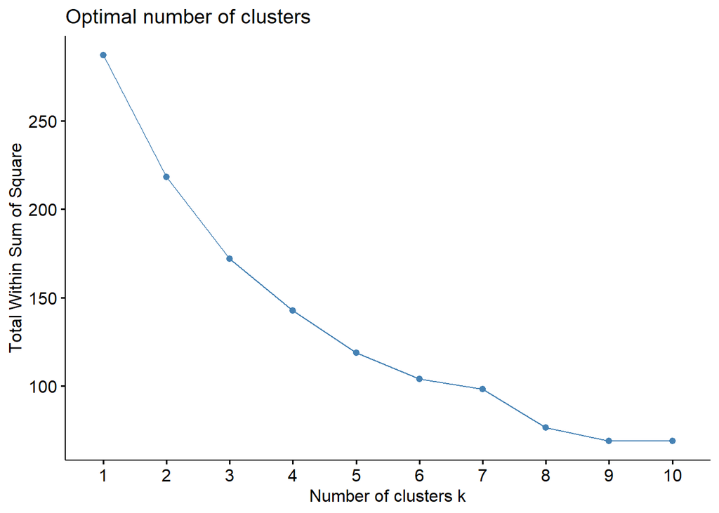

Wychodzi, że optymalna liczba klastrów to 9, ale drugą najlepszą liczbą klastrów jest 6

**Współczynnik sylwetki:**

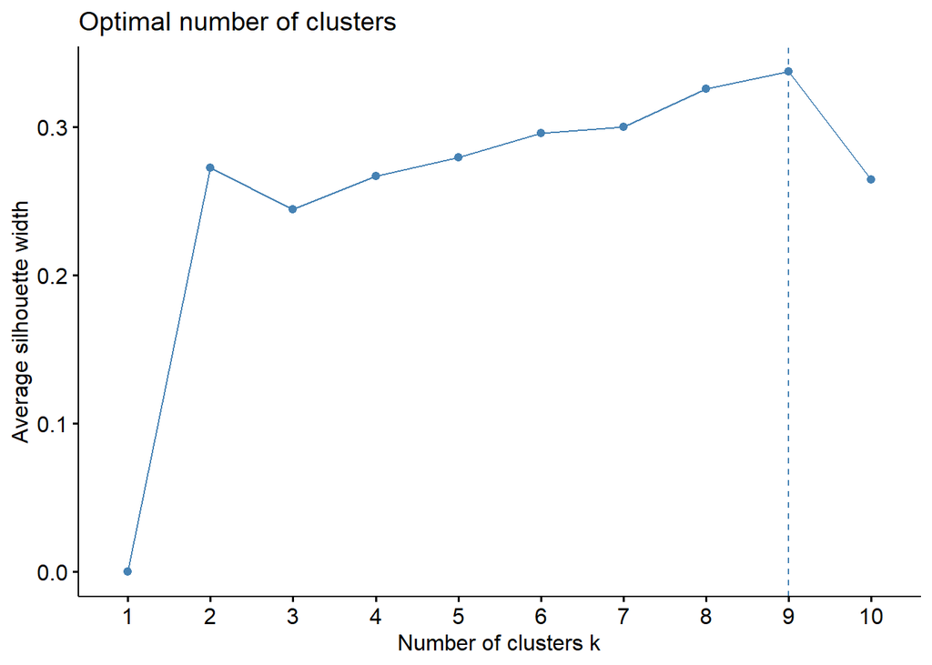

Tutaj także widzimy, że najlepsza liczba klastrów to 9.

**Kryterium Calinskiego-Harabasza:**

```
## [1] "Liczba klastrów: 2 Calinski-Harabasz Index: 16.4394074593909"
## [1] "Liczba klastrów: 3 Calinski-Harabasz Index: 15.0409638584514"
## [1] "Liczba klastrów: 4 Calinski-Harabasz Index: 15.5313265149737"
## [1] "Liczba klastrów: 5 Calinski-Harabasz Index: 14.6620084042701"
## [1] "Liczba klastrów: 6 Calinski-Harabasz Index: 14.2005885318958"
## [1] "Liczba klastrów: 7 Calinski-Harabasz Index: 12.7894682998209"
## [1] "Liczba klastrów: 8 Calinski-Harabasz Index: 14.1083292336092"
## [1] "Liczba klastrów: 9 Calinski-Harabasz Index: 13.2507077812394"
## [1] "Liczba klastrów: 10 Calinski-Harabasz Index: 13.9823163512604"
```

Według tego kryterium liczba klastrów 9 nie jest najlepsza, są lepsze przypisania klastrów, aby grupy wewnątrz siebie były podobne, a między sobą jak najbardziej rózne od siebie

Biorąc pod uwagę wszystkie metody przyjmuje k=6, gdyż przy wyborze k=9 są trzy grupy o liczności n=2. Liczba klastrów = 6 według wyżej podanych metod doboru też jest dobra.

## Przeprowadzenie analizy skupień metodą k-średnich:

```
##            item group1 vars  n        mean         sd      median     trimmed
## EDUCATION1    1      1    1 11  0.54912518 0.86824314  0.54912518  0.54912518
## EDUCATION2    2      2    1 13 -0.71808677 0.38074981 -0.82368777 -0.82368777
## EDUCATION3    3      3    1  3  1.46433381 0.79259392  1.92193812  1.46433381
## EDUCATION4    4      4    1  4  0.20592194 1.31436833 -0.13728129  0.20592194
## EDUCATION5    5      5    1  7  0.15689291 1.03774904  0.54912518  0.15689291
## EDUCATION6    6      6    1 10 -0.41184388 0.66313165 -0.82368777 -0.48048453
## AGE1          7      1    2 11  0.23445806 0.67071619  0.23445806  0.26131465
## AGE2          8      2    2 13 -0.72308277 0.52089516 -0.85323395 -0.76533965
## AGE3          9      3    2  3  1.72499896 0.87428419  2.16813274  1.72499896
## AGE4         10      4    2  4  0.92937239 0.71413417  0.71787673  0.92937239
## AGE5         11      5    2  7 -0.90502881 0.48269876 -0.97408862 -0.90502881
## AGE6         12      6    2 10  0.35531272 0.96178855  0.11360339  0.29488539
## MARRIAGE1    13      1    3 11 -1.07258323 0.00000000 -1.07258323 -1.07258323
## MARRIAGE2    14      2    3 13  0.91368201 0.00000000  0.91368201  0.91368201
## MARRIAGE3    15      3    3  3 -1.07258323 0.00000000 -1.07258323 -1.07258323
## MARRIAGE4    16      4    3  4 -1.07258323 0.00000000 -1.07258323 -1.07258323
## MARRIAGE5    17      5    3  7  0.91368201 0.00000000  0.91368201  0.91368201
## MARRIAGE6    18      6    3 10 -0.07945061 1.04685370 -0.07945061 -0.07945061
## PAY_MEAN1    19      1    4 11 -0.32518056 0.30865578 -0.47392584 -0.35789299
## PAY_MEAN2    20      2    4 13 -0.26279157 0.46020551 -0.49155804 -0.34648330
## PAY_MEAN3    21      3    4  3 -0.47806055 0.10424902 -0.47084562 -0.47806055
## PAY_MEAN4    22      4    4  4  0.06516321 0.28683987 -0.00794631  0.06516321
## PAY_MEAN5    23      5    4  7 -0.49560633 0.07091924 -0.48363270 -0.49560633
## PAY_MEAN6    24      6    4 10  0.64851756 1.04249235  0.41491841  0.54700589
## PAY_01       25      1    5 11 -0.59072308 0.43537929 -0.72199487 -0.72199487
## PAY_02       26      2    5 13 -0.72199487 0.00000000 -0.72199487 -0.72199487
## PAY_03       27      3    5  3  1.44398974 0.72199487  1.44398974  1.44398974
## PAY_04       28      4    5  4  1.44398974 0.00000000  1.44398974  1.44398974
## PAY_05       29      5    5  7  1.23770550 0.35229742  1.44398974  1.23770550
## PAY_06       30      6    5 10 -0.36099744 0.77984359 -0.72199487 -0.54149615
## LIMIT_BAL1   31      1    6 11 -0.40033794 0.54790545 -0.52674479 -0.38133560
## LIMIT_BAL2   32      2    6 13 -0.30653376 0.71178785 -0.03598877 -0.33341667
## LIMIT_BAL3   33      3    6  3 -0.99023659 0.47223020 -1.26287882 -0.99023659
## LIMIT_BAL4   34      4    6  4  0.20938923 0.43792827  0.16849290  0.20938923
## LIMIT_BAL5   35      5    6  7 -0.63190680 0.92382794 -1.09929348 -0.63190680
## LIMIT_BAL6   36      6    6 10  1.40356222 0.71117304  1.39538295  1.40560703
## BILL_MEAN1   37      1    7 11 -0.45012590 0.07780186 -0.48954419 -0.46006236
## BILL_MEAN2   38      2    7 13 -0.41677426 0.13109147 -0.48175453 -0.43524672
## BILL_MEAN3   39      3    7  3  0.08216123 0.78655783 -0.25763021  0.08216123
```

[output cut: 74 more lines]

```
## PAY_04     0.00000000
## PAY_05     0.13315591
## PAY_06     0.24660820
## LIMIT_BAL1 0.16519971
## LIMIT_BAL2 0.19741443
## LIMIT_BAL3 0.27264223
## LIMIT_BAL4 0.21896414
## LIMIT_BAL5 0.34917414
## LIMIT_BAL6 0.22489266
## BILL_MEAN1 0.02345814
## BILL_MEAN2 0.03635823
## BILL_MEAN3 0.45411937
## BILL_MEAN4 0.20419840
## BILL_MEAN5 0.18839383
## BILL_MEAN6 0.08054381
```

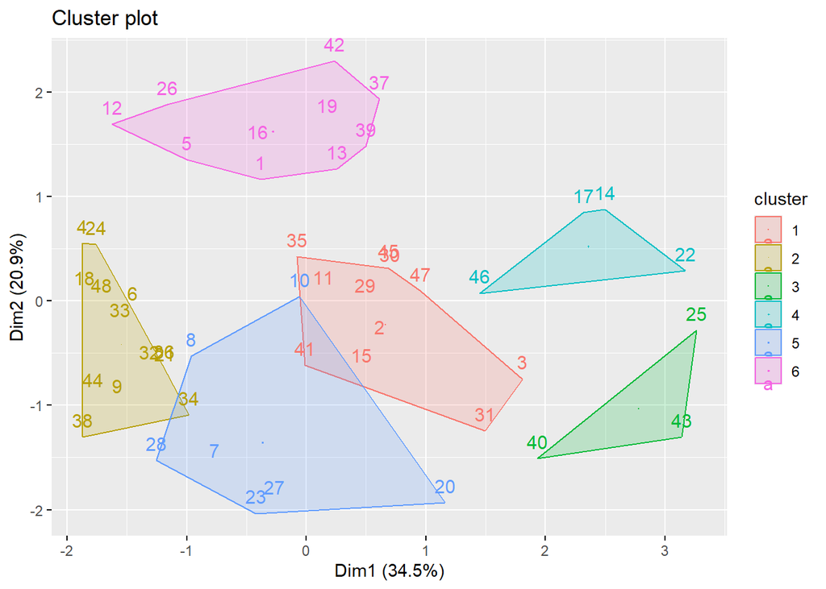

Grupa 1:

Wartości EDUCATION1, AGE1 i PAY_MEAN1 mają umiarkowane odchylenie standardowe. Średnia w EDUCATION wynosi 0,54 (ważne - są to dane standaryzowane), co świadczy że klienci mają niższe wykształcenie od ogołu i znajdują się w trzecim kwantylu. Średnia AGE jest troszkę wyższa od ogołu - czyli klienci średnio mają więcej niż 37 lat. Średnia PAY_MEAN jest trochę niższa od ogołu - czyli klienci płacą średnio mniej niż 6200$. W tej grupie są klienci, z których większośc zapłaciła na czas ostatni rachunek. podczas gdy MARRIAGE1 ma zerowe odchylenie standardowe, czyli wszyscy klienci w tej grupie są żonaci. Średnia w LIMIT BAL jest ujemna (-0.4), co wskazuje że klienci ci, mają niższy przyznany kredyt od ogołu (ok 180 000 $) i wystawiony mają mniejszy rachunek do zapłaty, średnia ogółu to ok 23 800 dolarów.

Grupa 2:

Ta grupa jest jednorodna - brak dużych odchyleń standardowych. EDUCATION2 i AGE2 mają średnie wartości ujemne (-0.72 i -0.72)z umiarkowanym odchyleniem standardowym, co oznacza że mają duzo wyższy poziom edukacji i są młodsi od ogołu, których wartości średnie wynoszą odpowiednio: -0.02 i -0.01 . MARRIAGE2 wynosi (0.914) dla wszystkich klientów, czyli wszyscy klienci w tej grupie są singlami. PAY_MEAN2 ma umiarkowane odchylenie standardowe (0.460) i jej średnia wartośc sugeruje, że klienci w tej grupie płacą niższe rachunki.Wszyscy klienci mają zapłacili ostatni rachunek na czas. Mają także niższy poziom zadłuzenia i niższe rachunki do zapłaty od ogółu klientów.

Grupa 3:

Grupa 5:

Grupa ta składa się z klientów, którzy są singlami, mają wykształcenie niższe od ogółu i są dużo młodsi. Płacą niższe rachunki od ogółu i mają średnio większe zaległości. Ich limit kredytu jest niższy od ogółu a średnie rachunku zbliżone.

**Podsumowanie**

Analizując wykres i statystyki wynika z tego, że grupy wewnątrz siebie nie różnią się znacząco (odchylenia standardowe poszczególnych cech rzadko przekraczają 1), a pomiędzy sobą są znaczne róznice, także k=6 jest odpowiednie.

## Klasteryzacja k-medoid za pomocą algorytmu PAM

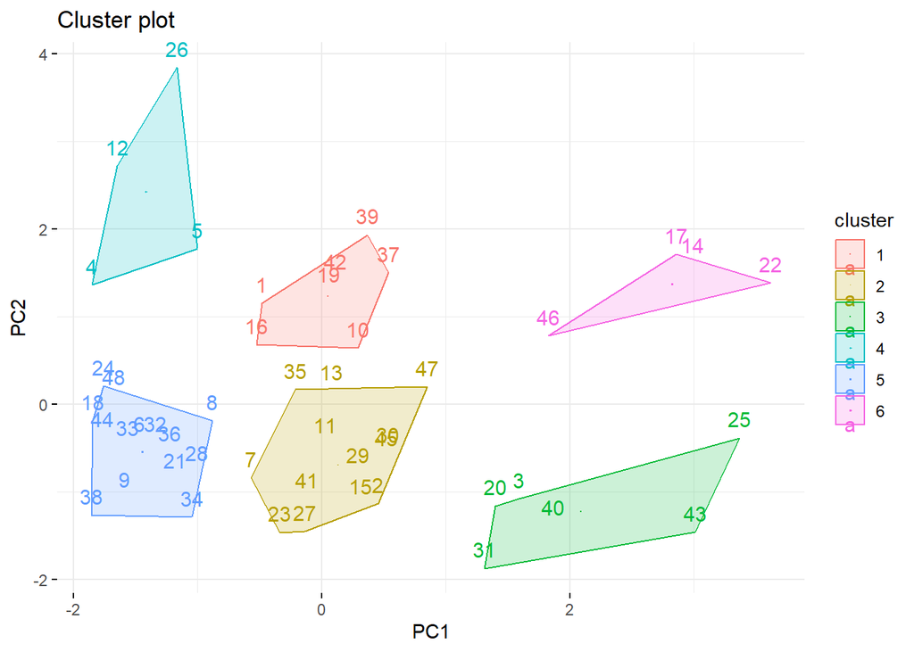

Ta metoda bardzo dobrze się sprawdza do tego zbioru danych. Klastry nie nachodzą na siebie, nie są zbyt mało liczne i grupy są odległe od siebie, czyli różnorodne. Widać pewne podobieństwa do poprzedniej metody, ale ta metoda sprawdziła się tutaj dużo lepiej.

## Hierarchiczna klasteryzacja metodą Warda z zastosowaniem macierzy odległości Euklidesowej

### Analiza indeksów ocen jakości klasyfikacji:

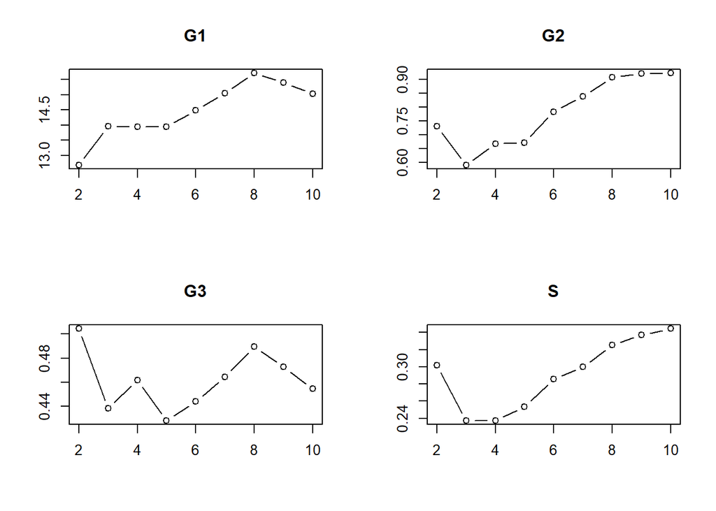

```
##  [1] 1 2 2 3 3 4 5 5 4 5 2 3 1 6 2 1 6 4 1 5 4 6 5 4 6 3 5 5 1 2 2 4 4 4 1 4 1 4
## [39] 1 6 2 1 6 4 2 6 2 4
```

**Wykres G1:**

**Wykres G2:**

### Wyciągnięcie liczby kroków wiązania

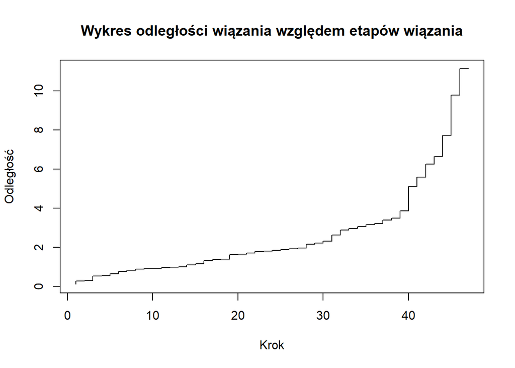

**Interpretacja klastrów**:

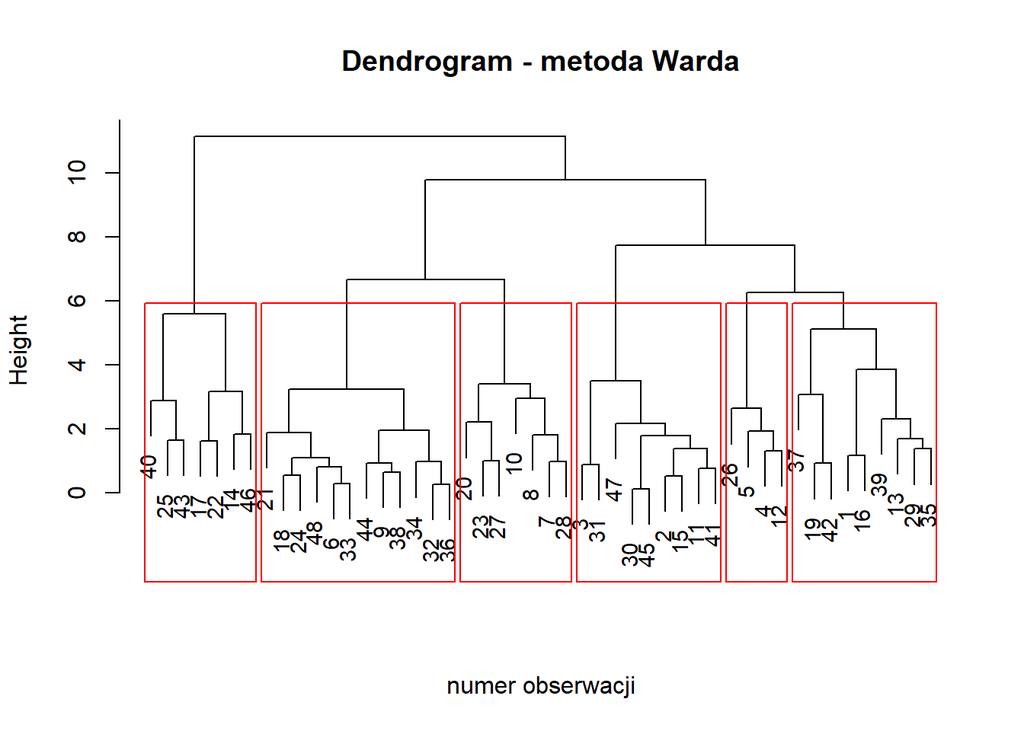

```
##   cluster EDUCATION.mean EDUCATION.sd EDUCATION.min EDUCATION.max    AGE.mean
## 1       1     -0.5186182    0.6053536    -0.8236878     0.5491252  0.74473332
## 2       2      0.8541947    0.6053536     0.5491252     1.9219381  0.14045998
## 3       3     -0.4804845    0.6864065    -0.8236878     0.5491252 -0.76259295
## 4       4     -0.7092867    0.3962970    -0.8236878     0.5491252 -0.68202317
## 5       5      0.1568929    1.0377490    -0.8236878     1.9219381 -0.90502881
## 6       6      0.7452413    1.2351684    -0.8236878     1.9219381  1.27035521
##        AGE.sd     AGE.min     AGE.max MARRIAGE.mean MARRIAGE.sd MARRIAGE.min
## 1  0.78503870 -0.36981528  1.80556873    -0.6311910   0.8758606   -1.0725832
## 2  0.65856862 -0.97408862  1.20129540    -1.0725832   0.0000000   -1.0725832
## 3  0.30213667 -1.21579796 -0.61152462     0.9136820   0.0000000    0.9136820
## 4  0.52162179 -1.33665262  0.35531272     0.9136820   0.0000000    0.9136820
## 5  0.48269876 -1.57836196 -0.00725128     0.9136820   0.0000000    0.9136820
## 6  0.83105239  0.35531272  2.28898740    -1.0725832   0.0000000   -1.0725832
##   MARRIAGE.max PAY_MEAN.mean PAY_MEAN.sd PAY_MEAN.min PAY_MEAN.max PAY_0.mean
```

[output cut: 20 more lines]

### Wyjaśnienie głównych elementów dendrogramu:

1. **Oś Y - Wysokość (Height)**:
   - Wysokość na osi Y reprezentuje odległość lub miarę niepodobieństwa, przy której klastry są łączone. Im wyżej na dendrogramie, tym większa jest odległość między klastrami.
2. **Oś X - ID**:
   - ID na osi X to identyfikatory poszczególnych klientów lub punktów danych. Na dole dendrogramu każdy punkt reprezentuje pojedynczego klienta.

Z dendrogramu wynika, że możemy rozważyć cięcie dendrogramu na różnych wysokościach, aby uzyskać różne liczby klastrów. Najlepsze jest cięcie na wysokości około 6-8, gdyż może dać nam kilka większych, zróżnicowanych klastrów, które są wciąż dość jednorodne wewnętrznie. Także warte uwagi jest cięcie na wysokości 4, które może dać liczbę bardziej jednorodnych klastrów. Sugerowana przeze mnie liczba klastrów na podstawie tego dendrogramu to 6. Wyniki z tego dendrogramu są zbliżone najbardziej do metody kmedoid (korelacja 65%)

Oto przypisania klastrów do klientów:

|  | ID | LIMIT_BAL | EDUCATION | MARRIAGE | AGE | PAY_0 | BILL_MEAN | PAY_MEAN | default payment next month | PC1 | PC2 | k_medoid | Ward |
| --- | --- | --- | --- | --- | --- | --- | --- | --- | --- | --- | --- | --- | --- |
| 1 | 12 | 0.6183525844827394 | -0.823687767580373 | 0.9136820096810567 | 1.684714066676684 | -0.7219948723811553 | -0.2007359595166758 | 0.4849893352134625 | 0 | -0.4797525793847766 | 1.158015923167065 | 1 | 1 |
| 2 | 22 | -0.5267447941890002 | 0.5491251783869151 | -1.072583228756023 | 0.2344580551902986 | -0.7219948723811553 | -0.5180206744082965 | -0.5927225634027151 | 1 | 0.4570916141141733 | -1.127563914580596 | 2 | 2 |
| 3 | 29 | -1.09929348352487 | 1.921938124354203 | -1.072583228756023 | 1.201295396181222 | -0.7219948723811553 | -0.3774471775141472 | 0.03975552788286048 | 0 | 1.591861442082551 | -1.078903726940221 | 3 | 2 |
| 4 | 31 | 0.3729745747673666 | -0.823687767580373 | 0.9136820096810567 | -1.215797956296086 | -0.7219948723811553 | -0.1076232629546893 | 1.004148504518107 | 0 | -1.852624357826198 | 1.366558942466376 | 4 | 3 |
| 5 | 49 | 1.59986462334423 | 0.5491251783869151 | 0.9136820096810567 | -0.6115246181767592 | -0.7219948723811553 | -0.1037009130857228 | 0.9349350518770947 | 0 | -1.001889467536952 | 1.775874994318969 | 4 | 3 |
| 6 | 59 | 0.1275965650519938 | -0.823687767580373 | 0.9136820096810567 | -0.3698152829290284 | -0.7219948723811553 | -0.5002214983424811 | -0.5873946093865678 | 0 | -1.468382135307957 | -0.4338259710348242 | 5 | 4 |
| 7 | 63 | -1.09929348352487 | -0.823687767580373 | 0.9136820096810567 | -0.9740886210483555 | 1.443989744762311 | 0.0535563301640774 | -0.5170489665171243 | 1 | -0.5709876797422017 | -0.8320518571496087 | 2 | 5 |
| 8 | 68 | 0.2093892349571181 | -0.823687767580373 | 0.9136820096810567 | -0.85323395342449 | 1.443989744762311 | -0.4934628749012872 | -0.4658839581058105 | 0 | -0.8829675860941749 | -0.185787750445986 | 5 | 5 |
| 9 | 71 | -0.8539154738094973 | -0.823687767580373 | 0.9136820096810567 | -0.7323792858006246 | -0.7219948723811553 | -0.5163915599631879 | -0.5865621165715449 | 0 | -1.58686839946768 | -1.071764641271218 | 5 | 4 |
| 10 | 72 | 1.109108603913485 | 0.5491251783869151 | 0.9136820096810567 | -0.9740886210483555 | 1.443989744762311 | 0.8038222389634576 | -0.3892613194110934 | 1 | 0.2915287169176051 | 0.6453552476343845 | 1 | 5 |

[output cut: 38 more lines]

```
## [1] 0.6500155
```

# Przykład wizualizacji klastrów na wykresie rozrzutu

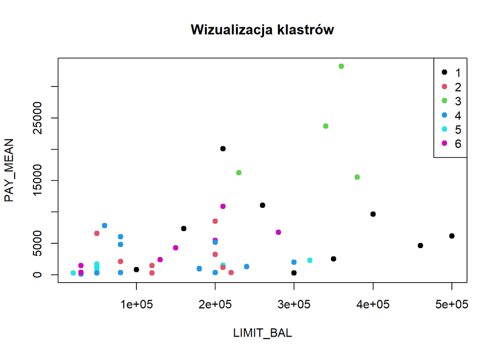

Pod względem tych cech grupy charakteryzują się:

1. Grupa 1: W większości wysokie przyznane kredyty, ale dośc wysokie średnie spłaty miesięczne
2. Grupa 2: Niższe kredyty do spłaty - do 200 000$, przy czym też mniejsze średnie spłaty miesięczne
3. Grupa 3: Wysokie kredyty i wysokie spłaty miesięczne
4. Grupa 4: Kredyty do ok 200 000 dolarów (tylko jedna osoba ma 300 000 dolarów), przy czym też mniejsze średnie spłaty miesięczne podobnie jak grupa 2
5. Grupa 5: Bardzo niskie kredyty do 50 000$, ale dwie osoby mają wybijają się ze schematu z kredytem 200 000 i ponad 300 000 dolarów, niskie średnie spłaty
6. Grupa 6: Kredyty do 300 000 dolarów, z charakterystyczną zależnością, że im wyższe kredyt, tym wyższA średnia spłata rachunku miesięcznie

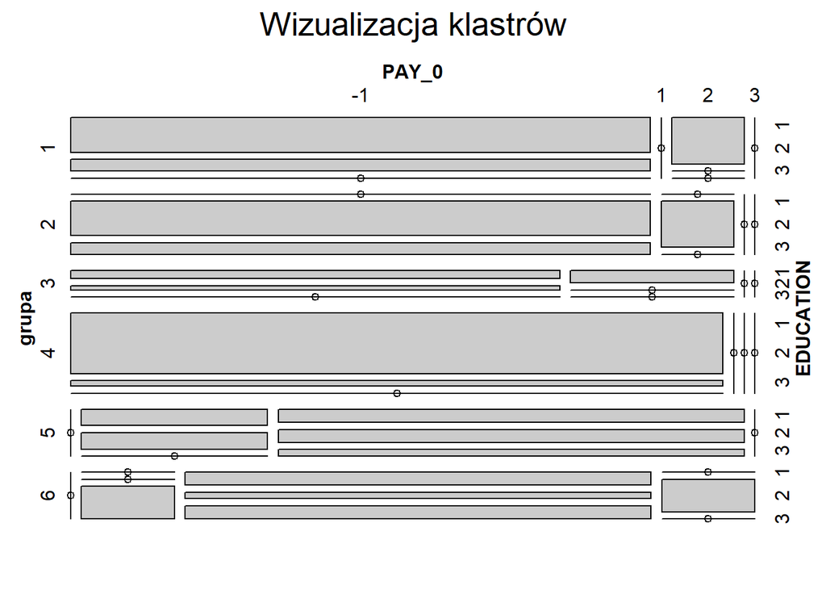

Pod względem tych cech grupy charakteryzują się:

1. Grupa 1: Składa się z większości osób, które płacą na czas i mają ukończoną szkołę podyplomową

2. Grupa 2: Klienci płacą zwykle na czas i mają w wi,ększości wykształcenie uniwesyteckie

3. Grupa 3: W większości płacą na czas, ale mają różne wykształcenia

4. Grupa 4: W zdecydowanej większości płacą na czas i mają wykształcenie wyższe niż średnie

5. Grupa 5: Mają najwięcej opóźnien 2-miesięcznych, w następnej kolejności 1-miesięczne i są zróżnicowani pod względem wykształcenia

6. Grupa 6: Składa się z dużej ilości osób opóznieniami 2-miesięcznymi, a w następnej kolejności z opóźnieniami 1,3-miesięcznymi

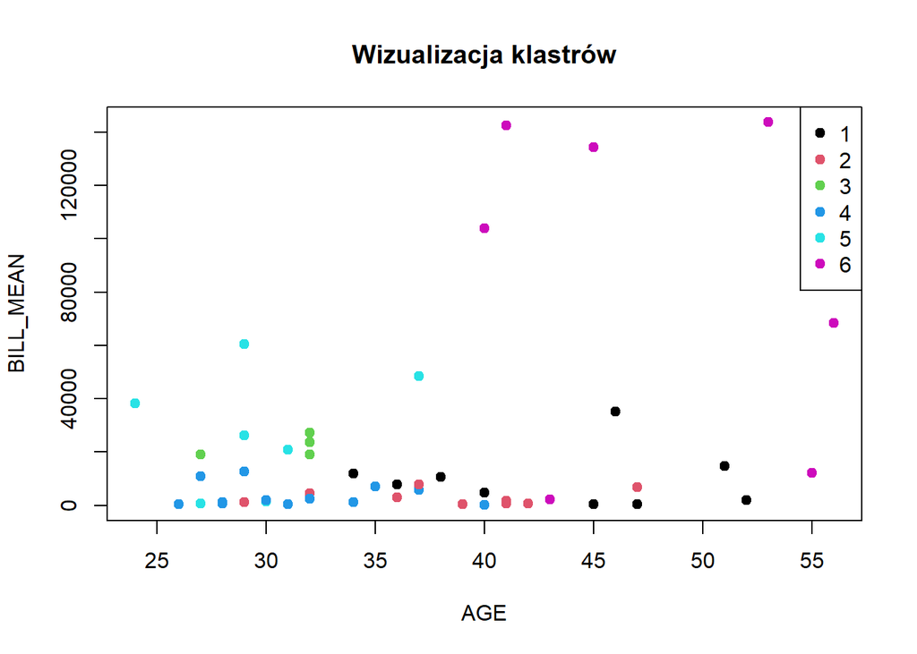

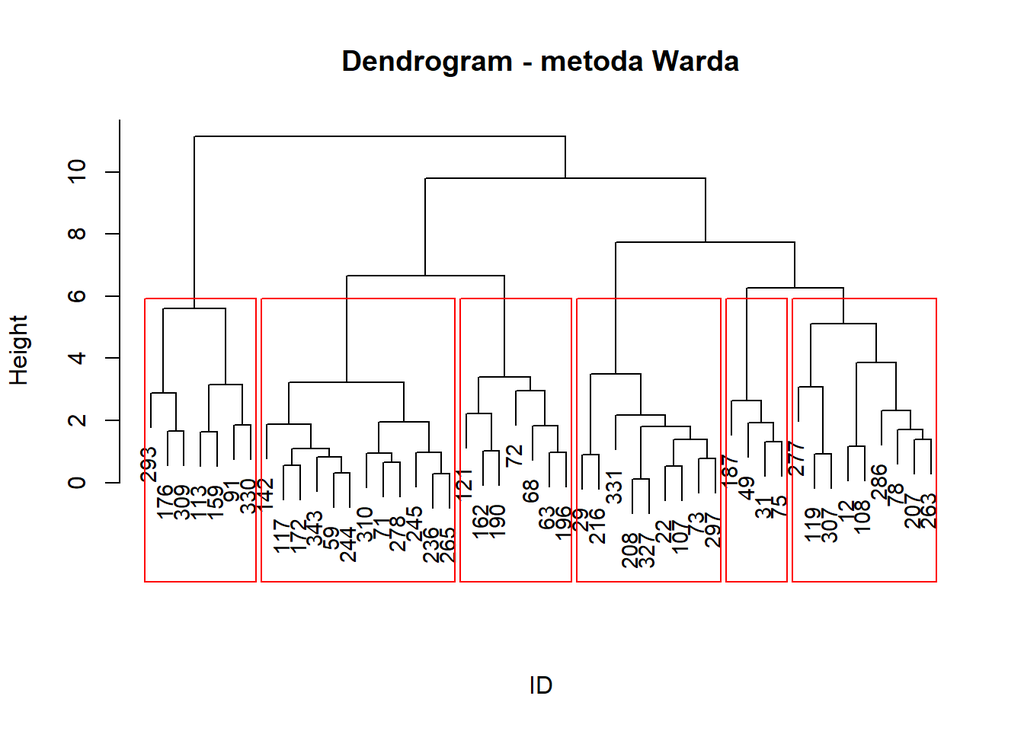

Tutaj po ID możemy porównać z porządkowanie liniowym, że 1 widoczna grupa to najbardziej zagrożeni niewypłacalnością klienci, reszta grup jest przydzielona według innych cech.

## Podsumowanie analizy skupień:

**Do obecnego zbioru danych najgorzej sprawdziła się metoda k-średnich spośród podanych, Chociaż metoda k-średnich również podzieliła dane na 6 klastrów, wyniki były mniej zadowalające w porównaniu do metody Warda czy k-medoid. Klasyfikacja nie była tak wyraźna, a interpretacja klastrów trudniejsza. W oparciu o przeprowadzoną analizę, metoda k-medoid i Warda była bardziej odpowiednia do analizy tego zbioru danych.**